# individual2

Caitlin Fordell

2/17/2021

```r
##Importing dataset
choco <- read.csv("https://raw.githubusercontent.com/xdaiISU/ds202materials/master/hwlabs/data/choco.csv")
str(choco)
```

```
## 'data.frame':    2312 obs. of  13 variables:
##  $ REF                 : int  2454 2458 2454 797 797 1015 1019 1011 1019 1011 ...
##  $ Company             : Factor w/ 541 levels "5150","A. Morin",..: 1 1 1 2 2 2 2 2 2 2 ...
##  $ Location            : Factor w/ 67 levels "Amsterdam","Argentina",..: 63 63 63 19 19 19 19 19 19 19 ...
##  $ Date                : int  2019 2019 2019 2012 2012 2013 2013 2013 2013 2013 ...
##  $ Bean_Origin         : Factor w/ 63 levels "Australia","Belize",..: 30 14 54 38 5 62 38 16 38 7 ...
##  $ Specific_Bean_Origin: Factor w/ 1436 levels "\"heirloom\", Arriba Nacional",..: 141 1435 666 1029 179 289 267 482 267 189 ...
##  $ Cocoa_Percent       : num  76 76 76 63 70 70 63 70 70 70 ...
##  $ Ingredients         : Factor w/ 21 levels "1- B","2- B,C",..: 7 7 7 14 14 14 7 14 14 14 ...
##  $ Characteristics1    : Factor w/ 450 levels "accesible","accessible",..: 81 81 311 131 430 272 403 328 81 240 ...
##  $ Characteristics2    : Factor w/ 502 levels "","\"Andes\" mint",..: 29 482 137 236 304 301 94 304 408 NA ...
##  $ Characteristics3    : Factor w/ 341 levels "","accessible",..: 115 260 29 251 NA 48 306 66 148 NA ...
##  $ Characteristics4    : Factor w/ 88 levels "acidic","apple",..: NA NA NA NA NA 66 NA 29 NA NA ...
##  $ Rating              : num  3.75 3.5 3.25 3.75 3.5 4 4 3.75 3.5 3.25 ...
```

```r
head(choco)
```

```
##    REF  Company Location Date        Bean_Origin   Specific_Bean_Origin
## 1 2454     5150   U.S.A. 2019         Madagascar Bejofo Estate, batch 1
## 2 2458     5150   U.S.A. 2019 Dominican Republic        Zorzal, batch 1
## 3 2454     5150   U.S.A. 2019           Tanzania  Kokoa Kamili, batch 1
## 4  797 A. Morin   France 2012               Peru                   Peru
## 5  797 A. Morin   France 2012            Bolivia                Bolivia
## 6 1015 A. Morin   France 2013          Venezuela                  Chuao
##   Cocoa_Percent Ingredients Characteristics1 Characteristics2 Characteristics3
## 1            76    3- B,S,C            cocoa       blackberry        full body
## 2            76    3- B,S,C            cocoa          vegetal           savory
## 3            76    3- B,S,C       rich cocoa            fatty           bready
## 4            63  4- B,S,C,L           fruity            melon           roasty
## 5            70  4- B,S,C,L          vegetal            nutty             <NA>
## 6            70  4- B,S,C,L             oily              nut          caramel
##   Characteristics4 Rating
## 1             <NA>   3.75
## 2             <NA>   3.50
## 3             <NA>   3.25
## 4             <NA>   3.75
## 5             <NA>   3.50
## 6        raspberry   4.00
```

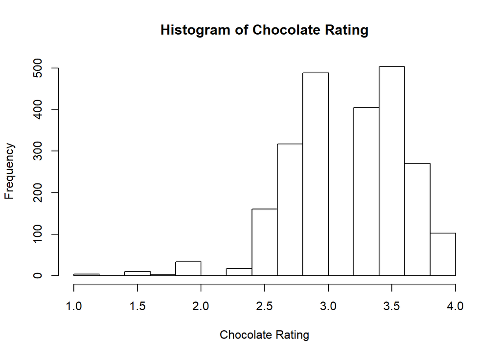

```r
##Problem 1
##histogram of chocolate rating
hist(choco$Rating, xlab = "Chocolate Rating", main = "Histogram of Chocolate Rating")
```

The histogram of chocolate ratings is unimodal and skewed to the left with a center around 3.25 and outliers around 1, 1.5, 1.75, and 2.

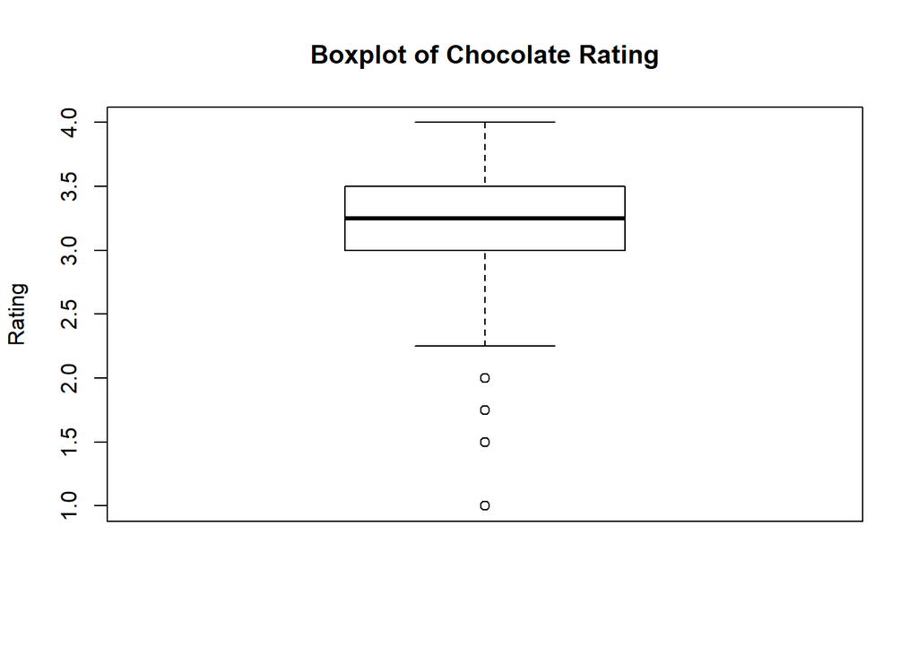

```r
##Problem 1
boxplot(choco$Rating, main = "Boxplot of Chocolate Rating", ylab = "Rating")
```

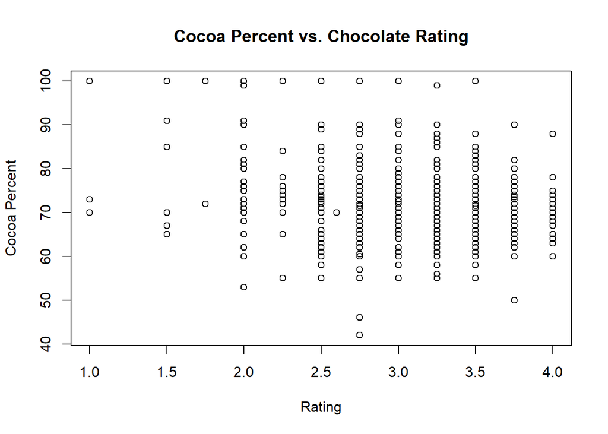

```r
##Problem 3
##Plotting cocoa percent and rating
plot(x = choco$Rating, y = choco$Cocoa_Percent, xlab = "Rating", ylab = "Cocoa Percent", main = "Cocoa Percent vs. Chocolate Rating")
```

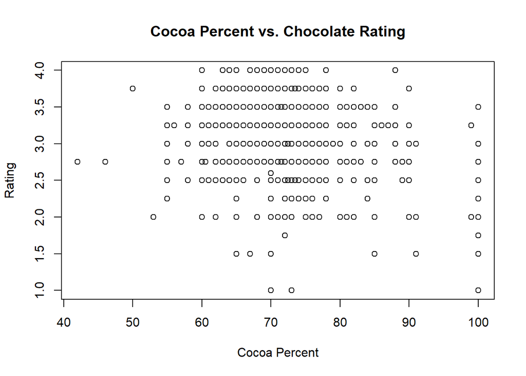

```r
##Problem 3
plot(x = choco$Cocoa_Percent, y = choco$Rating, xlab = "Cocoa Percent", ylab = "Rating", main = "Cocoa Percent vs. Chocolate Rating")
```

There appears to be a negative trend between the rating and the percent of cocoa. As cocoa percent increases, ratings tend to decrease.

```r
##Problem 3
##finding correlation between cocoa percent and rating
cor(x = choco$Cocoa_Percent, y = choco$Rating)
```

```
## [1] -0.1510178
```

There is a weak, negative relationship between cocoa percent and chocolate rating.

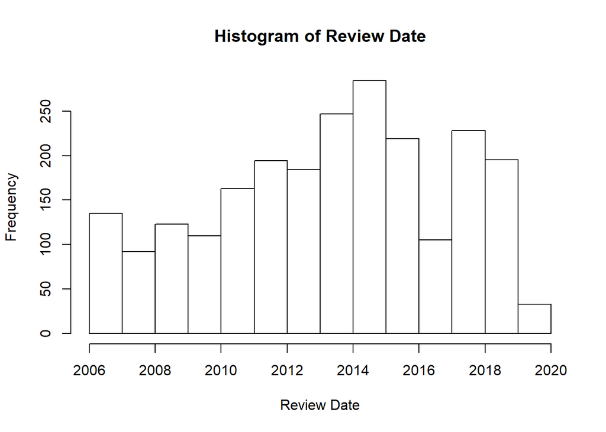

```r
##Problem 5
##histogram of review date
hist(choco$Date, xlab = "Review Date", main = "Histogram of Review Date")
```

Most of the reviews seemed to have been taken around 2014, and the company seemed take less reviews in 2016 and 2020.

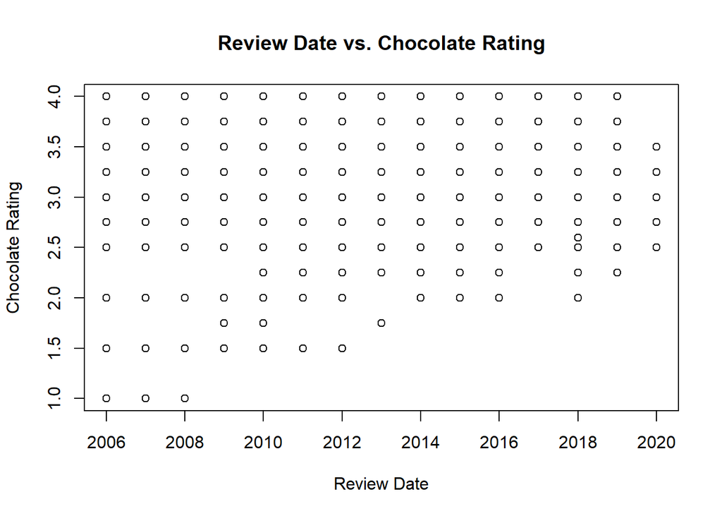

```r
##Problem 5
plot(x = choco$Date, y = choco$Rating, xlab = "Review Date", ylab = "Chocolate Rating", main = "Review Date vs. Chocolate Rating")
```

There seems to be a positive trend between review date and chocolate rating, meaning that in the more recent years, the chocolate ratings have been more consistently high.

```r
##Problem 5
cor(x = choco$Date, y = choco$Rating)
```

```
## [1] 0.08596685
```

There is a weak, positive correlation between chocolate ratings and review date.

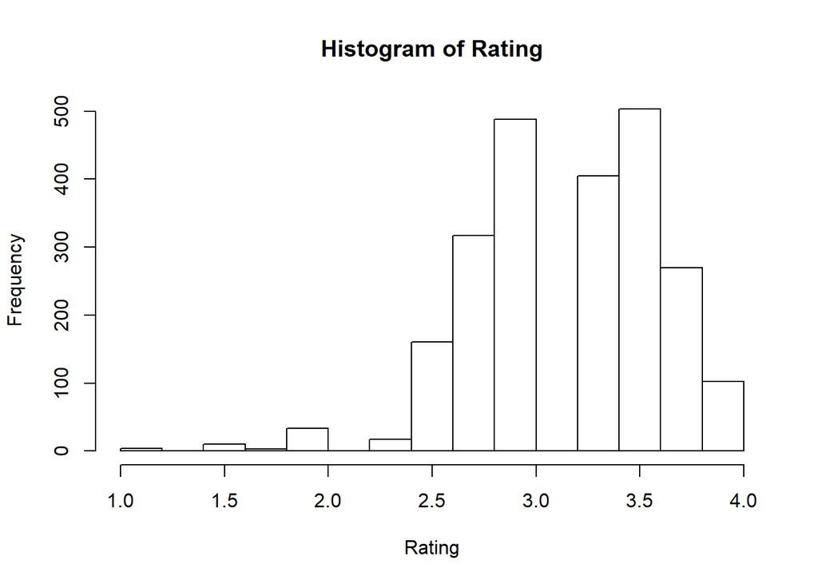

```r
##Problem 3 or 5
##creating a histogram of rating
hist(choco$Rating, xlab = "Rating", main = "Histogram of Rating")
```

```r
##Problem 3 or 5
##creating a summary of ratings
summary(choco$Rating)
```

```
##    Min. 1st Qu.  Median    Mean 3rd Qu.    Max.
##   1.000   3.000   3.250   3.184   3.500   4.000
```

The minimum rating was 1, the mean rating was 3.184, the median rating was 3.25, and the maximum rating was 4.